# Solution to Exercise 7.2

### 02409 Multivariate Statistics

`Week C`

**Principal Component Analysis on the ‘Fitness’ dataset**

the ‘Fitness’ dataset is presented in the **SAS Manuals on the Reg procedure**. It contains Data on Physical Fitness, and the “measurements were made on men involved in a physical fitness course at N.C. State Univ. The variables are Age (years), Weight (kg), Oxygen intake rate (ml per kg body weight per minute), time to run 1.5 miles (minutes), heart rate while resting, heart rate while running (same time Oxygen rate measured), and maximum heart rate recorded while |running. ***Certain values of MaxPulse were changed for this analysis”.

```r
Fit <- data.frame("Age" = c(44,40,44,42,38,47,40,43,44,38,44,45,45,47,54,49,51,51,48,49,57,54,52,50,51,54,51,57,49,48,52),
                  "Weight" = c(89.47,75.07,85.84,68.15,89.02,77.45,75.98,81.19,81.42,81.87,73.03,87.66,66.45,79.15,83.12,81.42,69.63,77.91,91.63,73.37,73.37,79.38,76.32,70.87,67.25,91.63,73.71,59.08,76.32,61.24,82.78),
                  "Oxygen" = c(44.609,45.313,54.297,59.571,49.874,44.811,45.681,49.091,39.442,60.055,50.541,37.388,44.754,47.273,51.855,49.156,40.836,46.672,46.774,50.388,39.407,46.08,45.441,54.625,45.118,39.203,45.79,50.545,48.673,47.92,47.467),
                  "Runtime" = c(11.37,10.07,8.65,8.17,9.22,11.63,11.95,10.85,13.08,8.63,10.13,14.03,11.12,10.60,10.33,8.95,10.95,10.00,10.25,10.08,12.63,11.17,9.63,8.92,11.08,12.88,10.47,9.93,9.40,11.50,10.50),
                  "RestPulse" = c(62,62,45,40,55,58,70,64,63,48,45,56,51,47,50,44,57,48,48,67,58,62,48,48,48,44,59,49,56,52,53),
                  "RunPulse" = c(178,185,156,166,178,176,176,162,174,170,168,186,176,162,166,180,168,162,162,168,174,156,164,146,172,168,186,148,186,170,170),
                 "MaxPulse" = c(182,185,168,172,180,176,180,170,176,186,168,192,176,164,170,185,172,168,164,168,176,165,166,155,172,172,188,155,188,176,172))
```

### A. Analysis on all variables

**1. In a principal component analysis, should we analyze the correlation- or the variance-covariance matrix? Why?**

```r
# Variance of each variable with either variance-covariance or correlation matrix
print("Variance in the diagonal for the variance-covariance matrix:")
t(diag(cov(Fit)))
print("Variance in the diagonal for the correlation matrix:")
t(diag(cor(Fit)))
```

```
## [1] "Variance in the diagonal for the variance-covariance matrix:"
```

```
##           Age   Weight   Oxygen  Runtime RestPulse RunPulse MaxPulse
## [1,] 27.15914 69.36504 28.37938 1.924918  58.05591 105.1032 83.98065
```

```
## [1] "Variance in the diagonal for the correlation matrix:"
```

```
##      Age Weight Oxygen Runtime RestPulse RunPulse MaxPulse
## [1,]   1      1      1       1         1        1        1
```

Since the units of the different variables are very different and not relevant to compare, we should analyze normalized data, i.e. look at the correlation matrix and not the dispersion (variance-covariance) matrix.

**2. Look at the eigenvalues and related plots (i.e. scree- and variance explained plots). How many components should we use? Perform statistical tests on the eigenvalues in order to test your intuition!**

We consider the analysis on all variables.

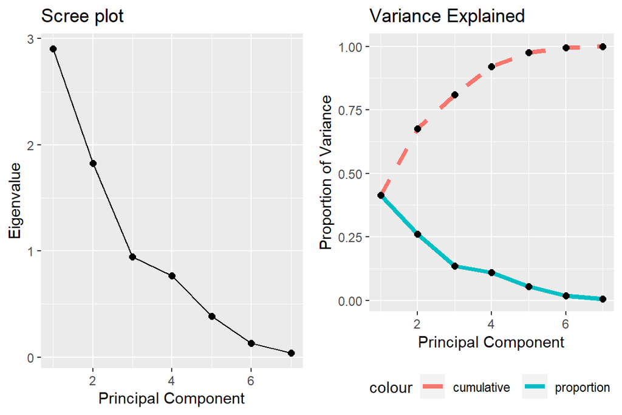

```r
pca <-princomp(Fit,cor=TRUE,scores=TRUE)
var <- pca$sdev^2
varPC <- var/sum(var)
cumu = c(1:7)
for (i in 1:7){
  cumu[i] = sum(varPC[1:i])
}
results <- data.frame("eigenvalues"=var,"proportion"=varPC,
                      "cumulative" = cumu)

# Scree plot
Scree_all = ggplot(results,aes(x=c(1:7),y=eigenvalues,group=1))+
  geom_line()+
  geom_point(size=2)+
  labs(x='Principal Component',y='Eigenvalue')+
  ggtitle('Scree plot')

# Variance Explained plot
Var_all = ggplot(results,aes(x=c(1:7),group=1))+
  geom_line(aes(y=cumulative,col = 'cumulative'),linetype = 'dashed',lwd=1.5)+
  geom_line(aes(y=proportion,col = 'proportion'),lwd=1.5)+
  geom_point(aes(y=cumulative),size=2)+
  geom_point(aes(y=proportion),size=2)+
  labs(x='Principal Component',y='Proportion of Variance')+
  theme(legend.position='bottom')+
  ggtitle('Variance Explained')

Scree_Var = list(Scree_all,Var_all)

ggarrange(plotlist = Scree_Var,ncol=2)
```

The scree-plot is not very clear, but we might consider keeping only the first 2 from looking at it, as it flattens from number 3. We want to keep those that are above the flat part of the plot. If we look at the variance explained, we also only keep the first 2, as it is only the first 2 eigenvalues that are larger than 1. Since we use the correlation matrix, all the original variables have variance 1. For a principal component to explain more of the variance than the original variables, it must thus have variance explained (i.e. eigenvalue) greater than 1.

If the last *k-m* eigenvalues are the same, they all explain the same degree of variance in the data, and it becomes arbitrary to include one and not another. The test statistic is given in **Theorem 6.8** for assessing whether say the last 4 eigenvalues may be considered to be equal

$${Z_{2}=-n \log \frac{\operatorname{det}
\hat{\mathbf{R}}}{\hat{\lambda}_{1} \cdot \ldots \cdot \hat{\lambda}_{m}
\cdot \hat{\lambda}^{k-m}}=-n \log \frac{\hat{\lambda}_{m+1} \cdot
\ldots \cdot \hat{\lambda}_{k}}{\hat{\lambda}_{*}^{k-m}}}$$

Where:

$${\hat{\lambda}_{*}=\left(k-\hat{\lambda}_{1}-\ldots-\hat{\lambda}_{m}\right)
/(k-)=\left(\hat{\lambda}_{m+1}+\ldots+\hat{\lambda}_{k}\right) /(k-m)}$$

$$Z_{2} =-31 \log \frac{\hat{\lambda}_4 \cdot \hat{\lambda}_5 \cdot
\hat{\lambda}_6 \cdot \hat{\lambda}_7}{\frac{(\hat{\lambda}_4 +
\hat{\lambda}_5 + \hat{\lambda}_6 + \hat{\lambda}_7)}{(7-3)}^{(7-3)}} =
-31\left\{ \sum_{i=4}^7 \ln\hat{\lambda}_i - 4\ln\hat{\lambda}\right\}$$

$$= -31(-6.45311671 + 4.42502657) = 62.8708$$

```r
#Theorem 6.8
n = length(Fit[,1])
ev = var
k = length(var)
m = 3
Z = -n * log(prod(ev[4:7])/((sum(ev[4:7])/(k-m))^(k-m)))
print(paste0("Z2 = ",Z))
dof = 1/2*(k-m+2)*(k-m-1)
print(paste0("P{chisq(9)>62.8708} = ",1-pchisq(Z,dof)))
```

```
## [1] "Z2 = 62.8707950858777"
```

```
## [1] "P{chisq(9)>62.8708} = 3.73733488601147e-10"
```

Since

$$P\{\chi^2(9)>62.8708\} = 0.0000$$

we reject the hypothesis about that the last 4 eigenvalues are equal for all reasonable levels of significance. Note that Theorem 6.8 is a quite sensitive test, and often it is better to rely on the scree plot or variance explained. We include it, as it is the only real test we have for the number of components in PCA.

### B. Exlude Age and Weight

**3. Repeat the above analyses!**

The scree plot is even less informative here. If we look at the eigenvalues, we would still keep the first 2, as they are greater than 1, and thus explain more of the variance than the original variables.

We can of course use Theorem 6.8 again, to test whether the last *k-m* eigenvalues are the same.

### C. Condition on Age and Weight

**4. Compare the partial correlations with correlations in Question *B*. Compare the eigenvalues and vectors with those from the results in B!**

**5. Are there big differences? If not: what can we then say about Age and Weight?**

We consider the random variables **Y** and **X** given by

$$\boldsymbol{Y}=\left[\begin{array}{c}
\text { Oxygen } \\
\text { RunTime } \\
\text { RestPulse } \\
\text { RunPulse } \\
\text { MaxPulse }
\end{array}\right] \quad \boldsymbol{X}=\left[\begin{array}{c}
\text { Age } \\
\text { Weight }
\end{array}\right]$$
with parameters
$$E\left[\begin{array}{l}
\boldsymbol{Y} \\
\boldsymbol{X}
\end{array}\right]=\left[\begin{array}{l}
\boldsymbol{\mu}_{y} \\
\boldsymbol{\mu}_{x}
\end{array}\right] \quad D\left[\begin{array}{l}
\boldsymbol{Y} \\
\boldsymbol{X}
\end{array}\right]=\left[\begin{array}{ll}
\boldsymbol{\Sigma}_{y y} & \boldsymbol{\Sigma}_{y x} \\
\boldsymbol{\Sigma}_{x y} & \boldsymbol{\Sigma}_{x x}
\end{array}\right]$$
Then we have the conditional dispersion (variance-covariance) matrix of $\boldsymbol{Y}$ given $\boldsymbol{X}$
$$D(\boldsymbol{Y} \mid
\boldsymbol{X}=\boldsymbol{x})=\boldsymbol{\Sigma}_{y
y}-\boldsymbol{\Sigma}_{y x} \boldsymbol{\Sigma}_{x x}^{-1}
\boldsymbol{\Sigma}_{x y}$$
Obviously
$$D(\boldsymbol{Y})=D(\boldsymbol{Y} \mid \boldsymbol{X}=\boldsymbol{x})$$

if

$$\Sigma_{yx} = 0$$

This may be tested by a single statistical test, but we shall evaluate this by looking at the individual elements.

```r
FitC <- data.frame(c(Fit[3:7],Fit[,1:2]))

Pearson_Correlation_Coef = corr.test(FitC,adjust = "none")
print("Pearson Correlation Coefficients:")
round(Pearson_Correlation_Coef$r,3)
print("P-values for each coefficient above:")
round(Pearson_Correlation_Coef$p,3)
```

```
## [1] "Pearson Correlation Coefficients:"
```

```
##           Oxygen Runtime RestPulse RunPulse MaxPulse    Age Weight
## Oxygen     1.000  -0.862    -0.399   -0.398   -0.237 -0.305 -0.163
## Runtime   -0.862   1.000     0.450    0.314    0.226  0.189  0.144
## RestPulse -0.399   0.450     1.000    0.352    0.305 -0.164  0.044
## RunPulse  -0.398   0.314     0.352    1.000    0.930 -0.338  0.182
## MaxPulse  -0.237   0.226     0.305    0.930    1.000 -0.433  0.249
## Age       -0.305   0.189    -0.164   -0.338   -0.433  1.000 -0.234
## Weight    -0.163   0.144     0.044    0.182    0.249 -0.234  1.000
```

```
## [1] "P-values for each coefficient above:"
```

```
##           Oxygen Runtime RestPulse RunPulse MaxPulse   Age Weight
## Oxygen     0.000   0.000     0.026    0.027    0.200 0.096  0.382
## Runtime    0.000   0.000     0.011    0.086    0.221 0.309  0.441
## RestPulse  0.026   0.011     0.000    0.052    0.095 0.378  0.814
## RunPulse   0.027   0.086     0.052    0.000    0.000 0.063  0.328
## MaxPulse   0.200   0.221     0.095    0.000    0.000 0.015  0.176
## Age        0.096   0.309     0.378    0.063    0.015 0.000  0.206
## Weight     0.382   0.441     0.814    0.328    0.176 0.206  0.000
```

```r
# Example of an individual Hypothesis test for correlation = 0.
# Correlation hypothesis test on Maxpulse and Age
E = cor(FitC)
n = length(FitC[,1])
r = E[5,6]
t = (r*sqrt(n-2))/(sqrt(1-r^2))
print("computed manually:")
2*(1-pt(abs(t),n-2))
print("computed from corr.test:")
Pearson_Correlation_Coef$p[5,6]
```

```
## [1] "computed manually:"
```

```
## [1] 0.01499135
```

```
## [1] "computed from corr.test:"
```

```
## [1] 0.01499135
```

All p-values for testing whether the given correlations are 0 are larger than 5% except the Age-MaxPulse correlation, where the p-value is 1.5%. It is therefore conceivable that (Age, Weight) is independent of the other variables. Therefore we will not observe big differences between the PCA analysis of Y and the PCA analysis of **Y** given **X** !

### D. Partial correlations based on Weight (by hand!)

**6. Reproduce some of the partial correlations, the test statistic for assessing whether the true partial correlations are zero and find the associated p-values!**

Partial correlation of $y_{1}$ and $y_{2}$ given $x$:

$$\large{\rho_{y_{1}y_{2} \mid x} = \frac{ \rho_{y_{1}y_{2}} - \rho_{y_{1}
x} \rho_{y_{2} x} }{\sqrt{(1-\rho^2_{y_{1}x})(1 - \rho^2_{y_{2}x})}}}$$

We determine the partial correlation between RunTime and MaxPulse given Weight:

$$\frac{0.22610 - 0.14351 \times
0.24938}{\sqrt{(1-0.14351^2)(1-0.24938^2)}} = 0.19858$$

The t-statistic becomes

$$\frac{0.19858}{\sqrt{(1-0.19858^2)}}\sqrt{31-2-1} = 1.07214$$

Since

$$P\{t(28) \leq 1.07214 \} = 0.85359$$

We accept the hypothesis that the partial correlation is equal to 0, and the probability of getting a more extreme t-value under the hypothesis is $2(1- 0.85359) = 0.29281$.

The p-value can be found in R by

```r
# Partial correlation based on Weights:
pcor_mat <- partial.r(cor(Fit),c(1,3:7),c(2))

# Partial correlation of Runtime and MaxPulse based on Weights
pcor <- pcor_mat[3,6]
print(paste0("Partial Correlation: ",pcor))

# from theorem 1.27
T = pcor/sqrt(1-pcor^2)*sqrt(n-2-(7-6))
print(paste0("T-statistic: ",T))
print(paste0("probability f getting a more extreme t-value under hypothesis: ",2*(1-pt(T,n-2-(7-6)))))
```

```
## [1] "Partial Correlation: 0.198579501919226"
```

```
## [1] "T-statistic: 1.07213577190411"
```

```
## [1] "probability f getting a more extreme t-value under hypothesis: 0.292813281624516"
```

## Annex

### Some output (mainly from the analysis on five variables)

**PCA on all variables:**

```r
print("Eigenvalues of the Correlation Matrix:")
results
print("Eigenvectors for PCA on all variables:")
pca$loadings[]
```

```
## [1] "Eigenvalues of the Correlation Matrix:"
```

```
##        eigenvalues  proportion cumulative
## Comp.1  2.90261161 0.414658801  0.4146588
## Comp.2  1.82759922 0.261085603  0.6757444
## Comp.3  0.94660947 0.135229924  0.8109743
## Comp.4  0.76417658 0.109168083  0.9201424
## Comp.5  0.38701492 0.055287846  0.9754303
## Comp.6  0.13146342 0.018780489  0.9942107
## Comp.7  0.04052478 0.005789254  1.0000000
```

```
## [1] "Eigenvectors for PCA on all variables:"
```

```
##               Comp.1      Comp.2       Comp.3      Comp.4     Comp.5
## Age        0.1401907  0.59568467  0.001259521  0.40814306  0.6470299
## Weight    -0.2003978 -0.16244166 -0.915337572 -0.13476909  0.2688242
## Oxygen     0.4206094 -0.46295066  0.103481222 -0.11563066  0.1868112
## Runtime   -0.4150668  0.44199320 -0.083272974 -0.07165505 -0.4662855
## RestPulse -0.3684690  0.09206125  0.308455905 -0.73907378  0.4629242
## RunPulse  -0.4935071 -0.25956185  0.184350482  0.37169788  0.1363167
## MaxPulse  -0.4600824 -0.36502542  0.124026793  0.33520482  0.1545452
##                 Comp.6       Comp.7
## Age        0.196021358  0.043033742
## Weight     0.020995949  0.068851758
## Oxygen     0.651972523  0.353155834
## Runtime    0.592651456  0.227232841
## RestPulse -0.005897817 -0.006829397
## RunPulse  -0.229875151  0.667464699
## MaxPulse   0.363254055 -0.609506326
```

**PCA on five variables:**

```r
Fit_5 <- Fit[,c(-1,-2)]
pc_5 <-princomp(Fit_5,cor=TRUE,scores=TRUE)
var_5 <- pc_5$sdev^2
varPC_5 <- var_5/sum(var_5)

cumu_5 = c(1:length(var_5))
for (i in 1:length(var_5)){
  cumu_5[i] = sum(varPC_5[1:i])
}
results_5 <- data.frame("eigenvalues"=var_5,"proportion"=varPC_5,
                      "cumulative" = cumu_5)
print("Eigenvalues of the Correlation Matrix:")
results_5
print("Eigenvectors for PCA on five variables:")
pc_5$loadings[,1] = -pc_5$loadings[,1]
pc_5$loadings[]
```

```
## [1] "Eigenvalues of the Correlation Matrix:"
```

```
##        eigenvalues  proportion cumulative
## Comp.1  2.80236541 0.560473081  0.5604731
## Comp.2  1.33190098 0.266380197  0.8268533
## Comp.3  0.67181253 0.134362506  0.9612158
## Comp.4  0.14925350 0.029850700  0.9910665
## Comp.5  0.04466758 0.008933516  1.0000000
```

```
## [1] "Eigenvectors for PCA on five variables:"
```

```
##               Comp.1     Comp.2      Comp.3      Comp.4      Comp.5
## Oxygen    -0.4685977  0.4360422  0.32215691  0.61807142  0.32324303
## Runtime    0.4589962 -0.4810267 -0.21250829  0.67870911  0.22831988
## RestPulse  0.3862342 -0.1413356  0.90859004 -0.06938734 -0.02229118
## RunPulse   0.4824342  0.4791285 -0.13350333 -0.25532096  0.67430050
## MaxPulse   0.4333809  0.5735335 -0.08772774  0.29553049 -0.62306173
```

**Note: For consistency of description between the outputs in SAS and in R, PC1 is multiplied by -1.**

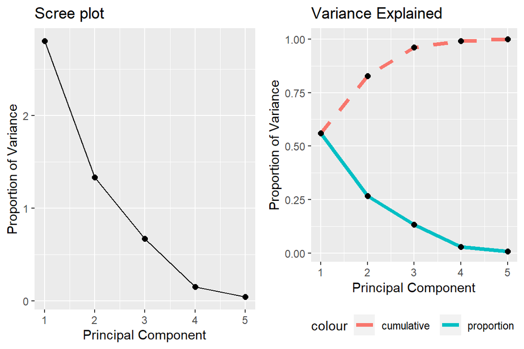

```r
# Scree plot
Scree_5 = ggplot(results_5,aes(x=c(1:5),y=eigenvalues,group=1))+
  geom_line()+
  geom_point(size=2)+
  labs(x='Principal Component',y='Proportion of Variance')+
  ggtitle('Scree plot')

# Variance Explained plot
Var_5 = ggplot(results_5,aes(x=c(1:5),group=1))+
  geom_line(aes(y=cumulative,col = 'cumulative'),linetype = 'dashed',lwd=1.5)+
  geom_line(aes(y=proportion,col = 'proportion'),lwd=1.5)+
  geom_point(aes(y=cumulative),size=2)+
  geom_point(aes(y=proportion),size=2)+
  labs(x='Principal Component',y='Proportion of Variance')+
  theme(legend.position='bottom')+
  ggtitle('Variance Explained')

Scree_Var_5 = list(Scree_5,Var_5)

ggarrange(plotlist = Scree_Var_5,ncol=2)
```

From as well table as Scree Plot and Variance Explained plot we see that two eigenvalues are larger than 1, and retaining two principal components will explain more than 80% of the total variation.

Since the correlations between the principal components and the original variables are (cf. slides from lecture)
$$\begin{bmatrix}
Corre(X_{1},Y_{1}) & Corre(X_{1},Y_{2}) \\
\vdots & \vdots\\
Corre(X_{k},Y_{1}) & Corre(X_{k},Y_{2}) \\
\end{bmatrix}
\quad$$
$$=\begin{bmatrix}
\boldsymbol{p_{1}} & \boldsymbol{p_{2}} \\
\end{bmatrix}\left[\begin{array}{l}
\sqrt{\lambda_{1}} & 0 \\
0 & \sqrt{\lambda_{2}}
\end{array}\right]$$
$$=\begin{bmatrix}
\sqrt{\lambda_{2}}\boldsymbol{p_{1}} &
\sqrt{\lambda_{2}}\boldsymbol{p_{2}} \\
\end{bmatrix}
\quad$$
we may compute those correlations easily from the eigenvalues and -vectors using a matrix manipulating language.

```r
di= diag(sqrt(var_5[1:2]))
pattern = pc_5$loadings[,1:2]%*%di
print("output for correlation between the PC and the original variables:")
pattern
```

```
## [1] "output for correlation between the PC and the original variables:"
```

```
##                 [,1]       [,2]
## Oxygen    -0.7844450  0.5032276
## Runtime    0.7683719 -0.5551434
## RestPulse  0.6465664 -0.1631126
## RunPulse   0.8076078  0.5529527
## MaxPulse   0.7254912  0.6619036
```

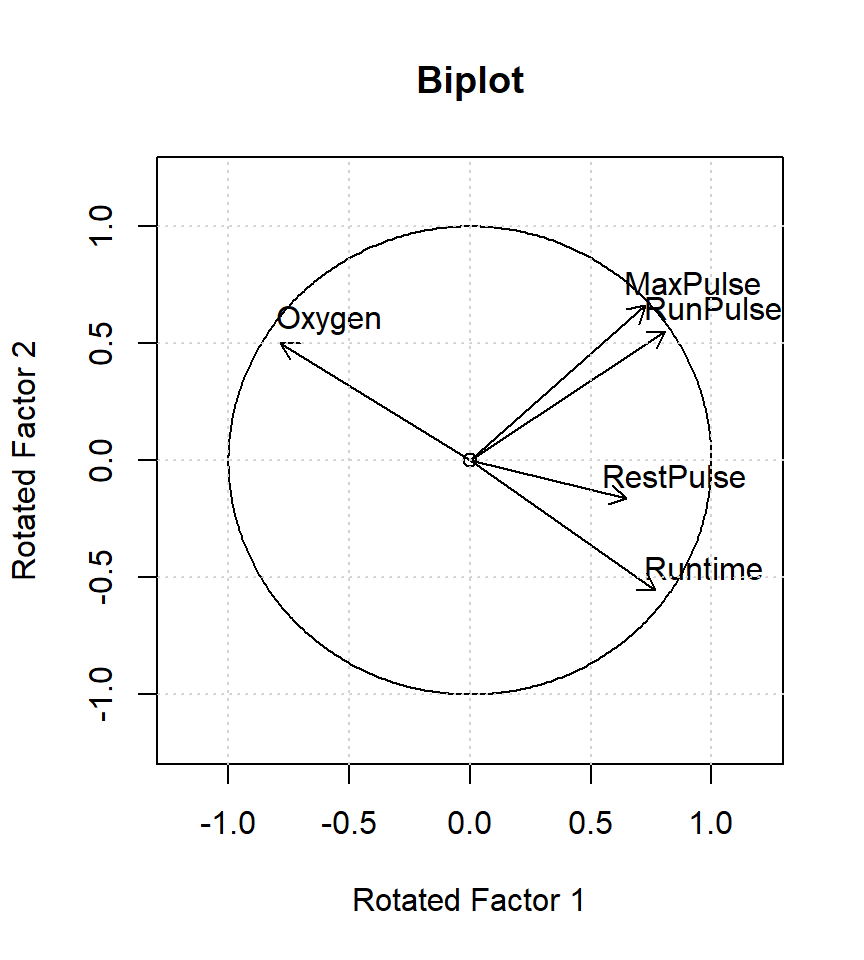

```r
#Biplot
circle = c(seq(-3.2,3.2,by=0.01))
plot(0,0,xlim = c(-1.2,1.2),ylim = c(-1.2,1.2),xlab = "Rotated Factor 1",
     ylab = "Rotated Factor 2",main = "Biplot")
points(1*cos(circle),1*sin(circle),type='l')
arrows(c(rep(0,7)),c(rep(0,7)),pattern[,1],pattern[,2],length = 0.1)
text(pattern[,1]+0.2,pattern[,2]+0.1,names(Fit_5))
grid()
```

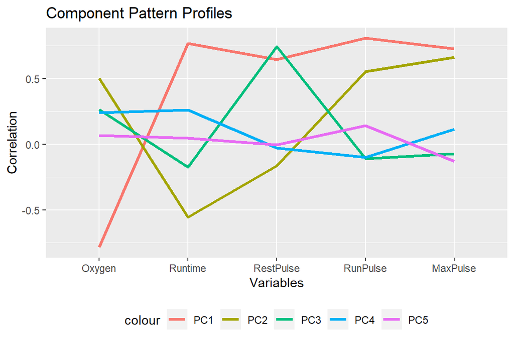

```r
#Pattern profile:
P <- pc_5$loadings[,1:5]
L <- diag(sqrt(pc_5$sdev^2))
corxy <- P%*%L

corxy<- data.frame("Variables" = c("Oxygen","Runtime","RestPulse","RunPulse","MaxPulse"),corxy)

pattern = ggplot(corxy,aes(x = Variables))+
  geom_line(aes(y=X1,group=1,col='PC1'),lwd=1.2)+
  geom_line(aes(y=X2,group=1,col='PC2'),lwd=1.2)+
  geom_line(aes(y=X3,group=1,col='PC3'),lwd=1.2)+
  geom_line(aes(y=X4,group=1,col='PC4'),lwd=1.2)+
  geom_line(aes(y=X5,group=1,col='PC5'),lwd=1.2)+
  labs(y="Correlation")+
  theme(legend.position = 'bottom')+
  ggtitle('Component Pattern Profiles')

pattern + scale_x_discrete(limits=c("Oxygen","Runtime","RestPulse","RunPulse","MaxPulse"))
```

In the **Component Pattern** plot we have mapped the points:

$$\begin{bmatrix} Corre(X_{i},Y_{1})\\ Corre(X_{i},Y_{2}) \end{bmatrix}
\textit{for i = oxygen,...,maxpulse.}$$
In the **Component Pattern Profiles** plot we have - for each j - mapped $Corre(X_{i},Y_{j})$ as a function of the original variable number i.

As well the raw eigenvectors as the two pattern plots are used in interpreting the principal components. We e.g. see that the first principal component is negatively correlated with the oxygen intake rate and positively with the remaining set of variables. Therefore a low value of PC1 (i.e. $Y_1$) corresponds to a person with high oxygen intake and low values of runtime,…,maxpulse, in other words a person that is very fit. A high value corresponds to a person with low oxygen intake and high values of runtime,…,maxpulse, i.e. a ‘non-fit’ person. Therefor we could say that **the first principal component corresponds to the fitness level of a person**.

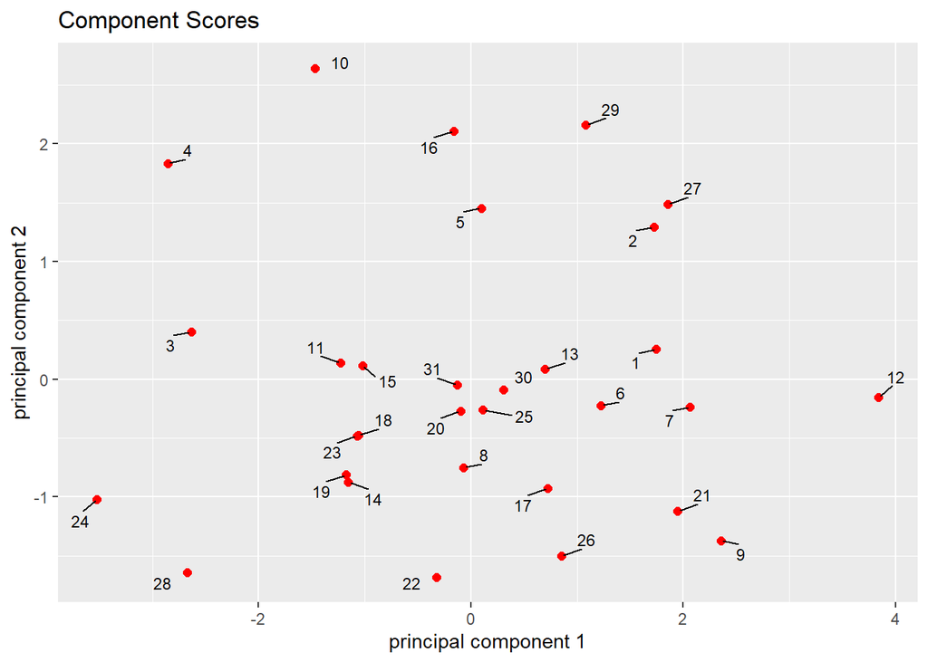

```r
#Component Scores
scores = data.frame(pc_5$scores)
# scores[,1] is multiplied by -1 to match the output from SAS.
ggplot(scores,aes(x = -1*scores[,1],y = scores[,2]))+
  geom_point(col = 'red',size = 2)+
  geom_text_repel(aes(label = c(1:31)),box.padding = 0.5,size=3)+
  labs(x = 'principal component 1',y = 'principal component 2')+
  ggtitle('Component Scores')
```

The **Component Scores** plot shows the values of then principal components for each of the original observations. If we look at person no. 24, his oxygen intake is the third best, his runtime the fourth best, restpulse no 5-10, runpulse the best, and his maxpulse no 1-2. Obviously no. 24 is a very fit person which corresponds well with the fact that he has the lowest value of PC1. Conversely, person no. 12 has the lowest oxygen intake, the highest maxpulse etc. Definitely not a very fit person - and has the highest PC1 score.

**PCA on partial correlation matrix:**

```r
partial_cor = partial.r(Fit,c(3:7),c(1:2))
pca_partial = eigen(partial_cor)

varp <- pca_partial$values
varPCp <- varp/sum(varp)
cumup = c(1:length(varp))
for (i in 1:length(varp)){
  cumup[i] = sum(varPCp[1:i])
}
results_partial <- data.frame("eigenvalues"=varp,"proportion"=varPCp,
                       "cumulative" = cumup)
print("Eigenvalues of the Correlation Matrix:")
results_partial
print("Eigenvectors for PCA on five variables:")
pca_partial$vectors
```

```
## [1] "Eigenvalues of the Correlation Matrix:"
```

```
##   eigenvalues  proportion cumulative
## 1  3.04243975 0.608487950  0.6084879
## 2  1.15407914 0.230815827  0.8393038
## 3  0.59993775 0.119987550  0.9592913
## 4  0.15514258 0.031028516  0.9903198
## 5  0.04840079 0.009680158  1.0000000
```

```
## [1] "Eigenvectors for PCA on five variables:"
```

```
##            [,1]       [,2]        [,3]        [,4]        [,5]
## [1,]  0.4938566 -0.3066075  0.36887622  0.63010444 -0.35916050
## [2,] -0.4580416  0.4330581 -0.36166812  0.64161316 -0.24533096
## [3,] -0.3637938  0.3732137  0.85295770 -0.02715564  0.00955804
## [4,] -0.4755129 -0.4916257  0.01160785 -0.26146879 -0.68094864
## [5,] -0.4334110 -0.5809202  0.07385746  0.34956772  0.58909596
```